# Lab 4 - Árboles de Decisión

Grupo #8 Osman Emanuel de León García - 23428 María José Yee Vidal - 231193 Andrés Rafael Chivalán Marroquín - 21534

2026-03-20

```r
library(dplyr)
library(tidyr)
library(ggplot2)
library(rpart)
library(rpart.plot)
library(caret)
library(Metrics)

set.seed(42)
```

# 1. Reutilización de conjuntos de entrenamiento y prueba (Actividad 1)

Se reutiliza exactamente el mismo preprocesamiento y split 80/20 del Lab 3, con `set.seed(42)` para garantizar reproducibilidad.

```r
# ── Carga y limpieza (idéntica al Lab 3) ──────────────────────────────────────
load("data/listings.RData")

listings$price <- as.numeric(gsub("[$,]", "", listings$price))

listings_clean <- listings %>%
  filter(!is.na(price), price > 0) %>%
  select(
    price,
    accommodates,
    bathrooms,
    bedrooms,
    beds,
    minimum_nights,
    maximum_nights,
    availability_30,
    availability_60,
    availability_90,
    availability_365,
    number_of_reviews,
    number_of_reviews_ltm,
    review_scores_rating,
    review_scores_cleanliness,
    review_scores_checkin,
    review_scores_communication,
    review_scores_location,
    review_scores_value,
    reviews_per_month,
    calculated_host_listings_count,
    host_listings_count,
    latitude,
    longitude
  ) %>%
  filter(!is.na(bedrooms), !is.na(bathrooms), !is.na(beds))

# Remover outliers extremos con 3×IQR (igual que Lab 3)
Q1        <- quantile(listings_clean$price, 0.25)
Q3        <- quantile(listings_clean$price, 0.75)
IQR_val   <- Q3 - Q1
limite_sup <- Q3 + 3 * IQR_val

listings_clean <- listings_clean %>%
  filter(price <= limite_sup)

# Agregar log_price
listings_clean$log_price <- log(listings_clean$price)

cat("Rango de price tras limpieza: $", min(listings_clean$price),
    "- $", max(listings_clean$price), "\n")
```

```
## Rango de price tras limpieza: $ 8 - $ 944
```

```r
# ── Dataset modelo (variables numéricas + NAs eliminados) ────────────────────
datos_modelo <- listings_clean %>%
  select(log_price, price, accommodates, bedrooms, bathrooms, beds,
         minimum_nights, availability_365, number_of_reviews,
         review_scores_rating, review_scores_cleanliness,
         review_scores_value, reviews_per_month,
         calculated_host_listings_count) %>%
  na.omit()

# ── Split 80/20 con la misma semilla ─────────────────────────────────────────
set.seed(42)
n         <- nrow(datos_modelo)
idx_train <- sample(1:n, size = floor(0.8 * n))
train     <- datos_modelo[idx_train, ]
test      <- datos_modelo[-idx_train, ]

cat("Total observaciones:", n, "\n")
```

```
## Total observaciones: 60343
```

```r
cat("Entrenamiento (80%):", nrow(train), "\n")
```

```
## Entrenamiento (80%): 48274
```

```r
cat("Prueba       (20%):", nrow(test),  "\n")
```

```
## Prueba       (20%): 12069
```

**Justificación:** Se mantiene la misma partición del Lab 3 para que las comparaciones entre regresión lineal y árboles de decisión sean directas y reproducibles. El dataset final cuenta con 60,343 observaciones tras la limpieza y remoción de outliers.

# 2. Árbol de Regresión — todas las variables (Actividad 2)

Se entrena un árbol de regresión con `rpart` usando `log_price` como variable respuesta y todas las variables numéricas disponibles.

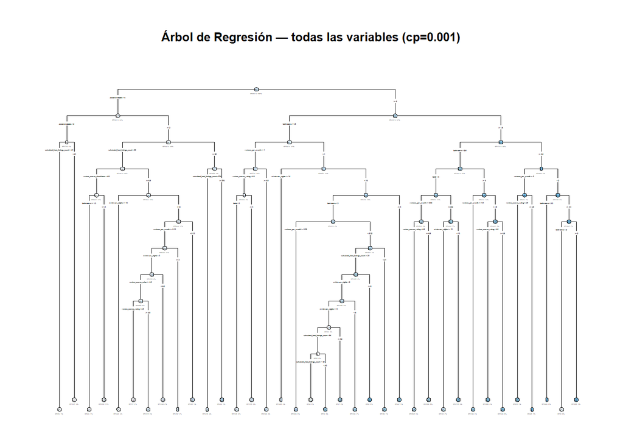

```r
# Árbol de regresión con todos los predictores, sin restricción de profundidad
arbol_reg_full <- rpart(
  log_price ~ accommodates + bedrooms + bathrooms + beds +
              minimum_nights + availability_365 + number_of_reviews +
              review_scores_rating + review_scores_cleanliness +
              review_scores_value + reviews_per_month +
              calculated_host_listings_count,
  data    = train,
  method  = "anova",
  control = rpart.control(cp = 0.001)   # cp pequeño → árbol más profundo
)

# Visualización del árbol completo
rpart.plot(
  arbol_reg_full,
  type    = 4,
  extra   = 101,
  under   = TRUE,
  tweak   = 0.8,
  main    = "Árbol de Regresión — todas las variables (cp=0.001)"
)
```

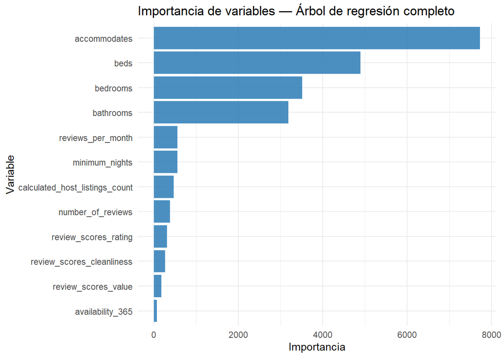

```r
# Importancia de variables
imp_full <- arbol_reg_full$variable.importance
imp_df   <- data.frame(
  variable    = names(imp_full),
  importancia = as.numeric(imp_full)
) %>% arrange(desc(importancia))

ggplot(imp_df, aes(x = reorder(variable, importancia), y = importancia)) +
  geom_col(fill = "#2C7BB6", alpha = 0.85) +
  coord_flip() +
  labs(title = "Importancia de variables — Árbol de regresión completo",
       x = "Variable", y = "Importancia") +
  theme_minimal()
```

# 3. Predicción y análisis del árbol base (Actividad 3)

```r
# Predicciones sobre el conjunto de prueba
pred_arbol_full <- predict(arbol_reg_full, newdata = test)

# Métricas de evaluación
r2_arbol_full   <- 1 - sum((test$log_price - pred_arbol_full)^2) /
                       sum((test$log_price - mean(test$log_price))^2)
rmse_arbol_full <- sqrt(mean((test$log_price - pred_arbol_full)^2))
mae_arbol_full  <- mean(abs(test$log_price - pred_arbol_full))

cat("=== Árbol de regresión — todas las variables ===\n")
```

```
## === Árbol de regresión — todas las variables ===
```

```r
cat("R²  :", round(r2_arbol_full,   4), "\n")
```

```
## R²  : 0.5013
```

```r
cat("RMSE:", round(rmse_arbol_full, 4), "\n")
```

```
## RMSE: 0.4753
```

```r
cat("MAE :", round(mae_arbol_full,  4), "\n")
```

```
## MAE : 0.3721
```

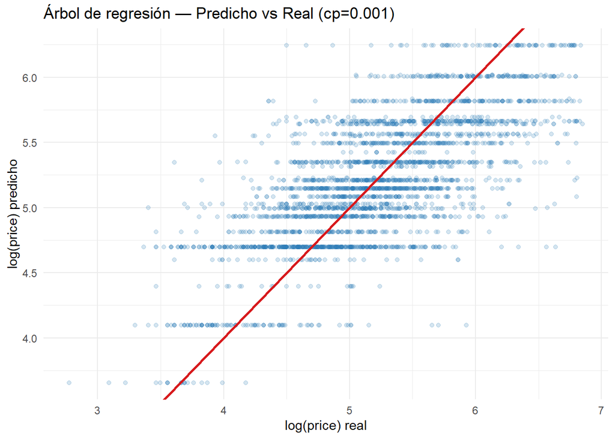

```r
# Gráfica predicho vs real
set.seed(42)
idx_viz <- sample(1:nrow(test), 3000)
df_viz  <- data.frame(
  real     = test$log_price[idx_viz],
  predicho = pred_arbol_full[idx_viz]
)

ggplot(df_viz, aes(x = real, y = predicho)) +
  geom_point(alpha = 0.2, color = "#2C7BB6") +
  geom_abline(slope = 1, intercept = 0, color = "#D7191C", linewidth = 1) +
  labs(title = "Árbol de regresión — Predicho vs Real (cp=0.001)",
       x = "log(price) real", y = "log(price) predicho") +
  theme_minimal()
```

# 4. Tuneo de la profundidad del árbol (Actividad 4)

```r
# Función auxiliar de métricas
metricas_arbol <- function(modelo, datos_test, nombre) {
  pred  <- predict(modelo, newdata = datos_test)
  r2    <- 1 - sum((datos_test$log_price - pred)^2) /
               sum((datos_test$log_price - mean(datos_test$log_price))^2)
  rmse  <- sqrt(mean((datos_test$log_price - pred)^2))
  mae   <- mean(abs(datos_test$log_price - pred))
  data.frame(Modelo = nombre,
             MaxDepth = NA,
             R2   = round(r2,   4),
             RMSE = round(rmse, 4),
             MAE  = round(mae,  4))
}

# Profundidades a explorar
profundidades <- c(3, 5, 8, 12, 20)
resultados_reg <- data.frame()

for (d in profundidades) {
  modelo_d <- rpart(
    log_price ~ accommodates + bedrooms + bathrooms + beds +
                minimum_nights + availability_365 + number_of_reviews +
                review_scores_rating + review_scores_cleanliness +
                review_scores_value + reviews_per_month +
                calculated_host_listings_count,
    data    = train,
    method  = "anova",
    control = rpart.control(maxdepth = d, cp = 0.0001)
  )
  pred_d   <- predict(modelo_d, newdata = test)
  r2_d     <- 1 - sum((test$log_price - pred_d)^2) /
                  sum((test$log_price - mean(test$log_price))^2)
  rmse_d   <- sqrt(mean((test$log_price - pred_d)^2))
  mae_d    <- mean(abs(test$log_price - pred_d))

  resultados_reg <- bind_rows(resultados_reg,
    data.frame(Modelo   = paste0("maxdepth=", d),
               MaxDepth = d,
               R2       = round(r2_d,   4),
               RMSE     = round(rmse_d, 4),
               MAE      = round(mae_d,  4))
  )
}

print(resultados_reg)
```

```
##        Modelo MaxDepth     R2   RMSE    MAE
## 1  maxdepth=3        3 0.4459 0.5010 0.3932
## 2  maxdepth=5        5 0.4865 0.4824 0.3762
## 3  maxdepth=8        8 0.5227 0.4650 0.3612
## 4 maxdepth=12       12 0.5328 0.4601 0.3563
## 5 maxdepth=20       20 0.5287 0.4621 0.3562
```

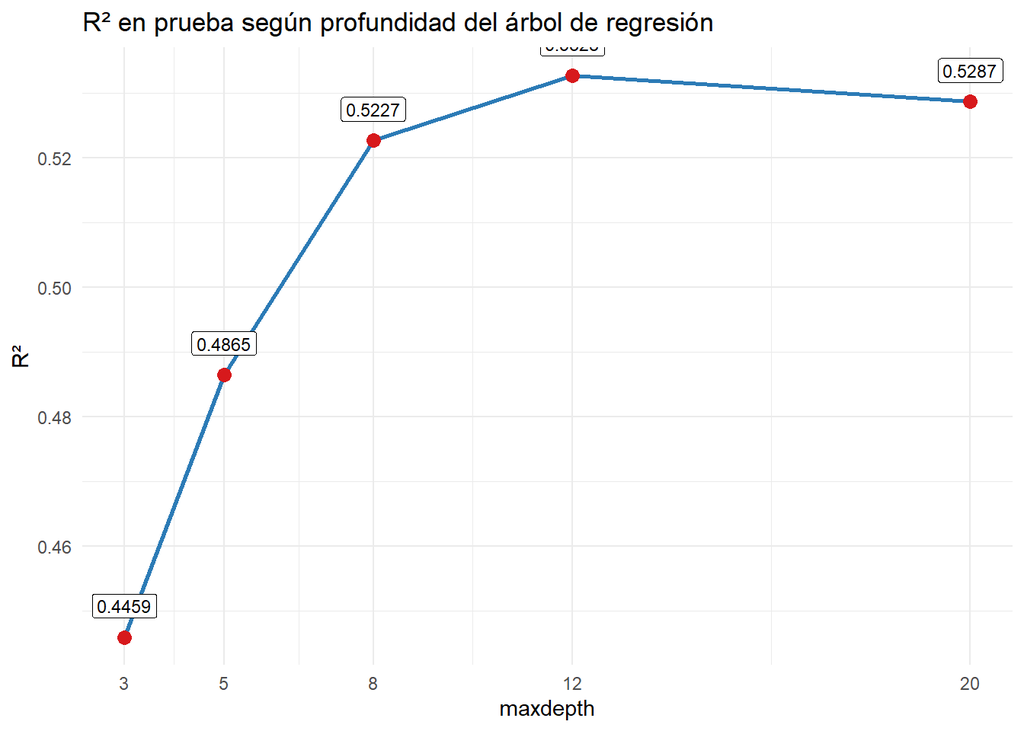

```r
# Gráfica R² vs profundidad
ggplot(resultados_reg, aes(x = MaxDepth, y = R2)) +
  geom_line(color = "#2C7BB6", linewidth = 1) +
  geom_point(color = "#D7191C", size = 3) +
  geom_label(aes(label = R2), vjust = -0.8, size = 3) +
  scale_x_continuous(breaks = profundidades) +
  labs(title = "R² en prueba según profundidad del árbol de regresión",
       x = "maxdepth", y = "R²") +
  theme_minimal()
```

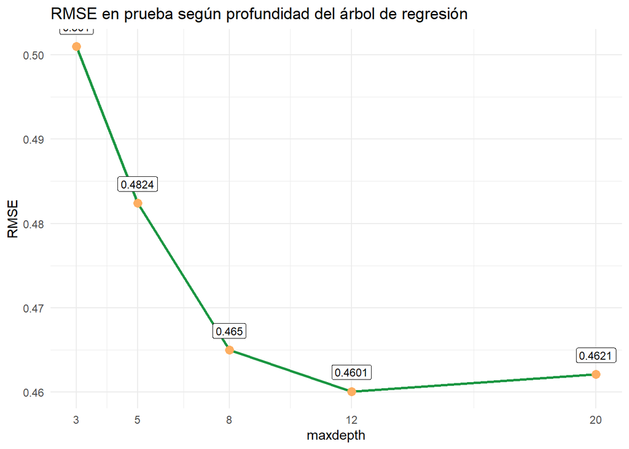

```r
# Gráfica RMSE vs profundidad
ggplot(resultados_reg, aes(x = MaxDepth, y = RMSE)) +
  geom_line(color = "#1A9641", linewidth = 1) +
  geom_point(color = "#FDAE61", size = 3) +
  geom_label(aes(label = RMSE), vjust = -0.8, size = 3) +
  scale_x_continuous(breaks = profundidades) +
  labs(title = "RMSE en prueba según profundidad del árbol de regresión",
       x = "maxdepth", y = "RMSE") +
  theme_minimal()
```

```r
# Seleccionar mejor modelo
idx_mejor_reg  <- which.max(resultados_reg$R2)
mejor_depth    <- resultados_reg$MaxDepth[idx_mejor_reg]
cat("\nMejor profundidad:", mejor_depth,
    "| R²:", resultados_reg$R2[idx_mejor_reg],
    "| RMSE:", resultados_reg$RMSE[idx_mejor_reg], "\n")
```

```
##
## Mejor profundidad: 12 | R²: 0.5328 | RMSE: 0.4601
```

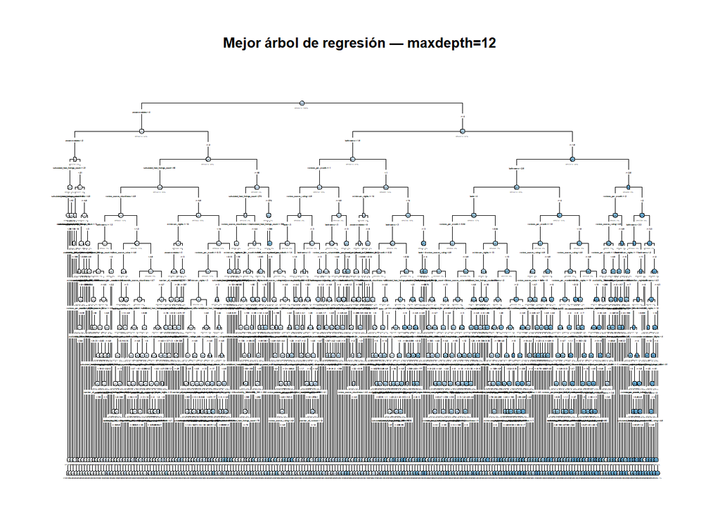

```r
# Entrenar y graficar el mejor árbol
arbol_reg_mejor <- rpart(
  log_price ~ accommodates + bedrooms + bathrooms + beds +
              minimum_nights + availability_365 + number_of_reviews +
              review_scores_rating + review_scores_cleanliness +
              review_scores_value + reviews_per_month +
              calculated_host_listings_count,
  data    = train,
  method  = "anova",
  control = rpart.control(maxdepth = mejor_depth, cp = 0.0001)
)

rpart.plot(
  arbol_reg_mejor,
  type  = 4,
  extra = 101,
  under = TRUE,
  tweak = 0.8,
  main  = paste0("Mejor árbol de regresión — maxdepth=", mejor_depth)
)
```

# 5. Comparación árbol de regresión vs regresión lineal (Actividad 5)

```r
# ── Re-entrenar el mejor modelo lineal del Lab 3 (Depurado) ──────────────────
modelo_lineal_dep <- lm(
  log_price ~ accommodates + bathrooms +
              minimum_nights + availability_365 + number_of_reviews +
              review_scores_rating + review_scores_cleanliness +
              review_scores_value + reviews_per_month +
              calculated_host_listings_count,
  data = train
)

pred_lineal_test <- predict(modelo_lineal_dep, newdata = test)

r2_lineal   <- 1 - sum((test$log_price - pred_lineal_test)^2) /
                   sum((test$log_price - mean(test$log_price))^2)
rmse_lineal <- sqrt(mean((test$log_price - pred_lineal_test)^2))
mae_lineal  <- mean(abs(test$log_price - pred_lineal_test))

# ── Predicciones del mejor árbol ─────────────────────────────────────────────
pred_mejor_arbol <- predict(arbol_reg_mejor, newdata = test)

r2_arbol_opt   <- 1 - sum((test$log_price - pred_mejor_arbol)^2) /
                      sum((test$log_price - mean(test$log_price))^2)
rmse_arbol_opt <- sqrt(mean((test$log_price - pred_mejor_arbol)^2))
mae_arbol_opt  <- mean(abs(test$log_price - pred_mejor_arbol))

# ── Tabla comparativa ─────────────────────────────────────────────────────────
comparacion <- data.frame(
  Algoritmo = c("Regresión Lineal (Depurada)",
                paste0("Árbol de Regresión (maxdepth=", mejor_depth, ")")),
  R2   = round(c(r2_lineal,        r2_arbol_opt),   4),
  RMSE = round(c(rmse_lineal,      rmse_arbol_opt), 4),
  MAE  = round(c(mae_lineal,       mae_arbol_opt),  4)
)

print(comparacion)
```

```
##                          Algoritmo     R2   RMSE    MAE
## 1      Regresión Lineal (Depurada) 0.4096 0.5172 0.4030
## 2 Árbol de Regresión (maxdepth=12) 0.5328 0.4601 0.3563
```

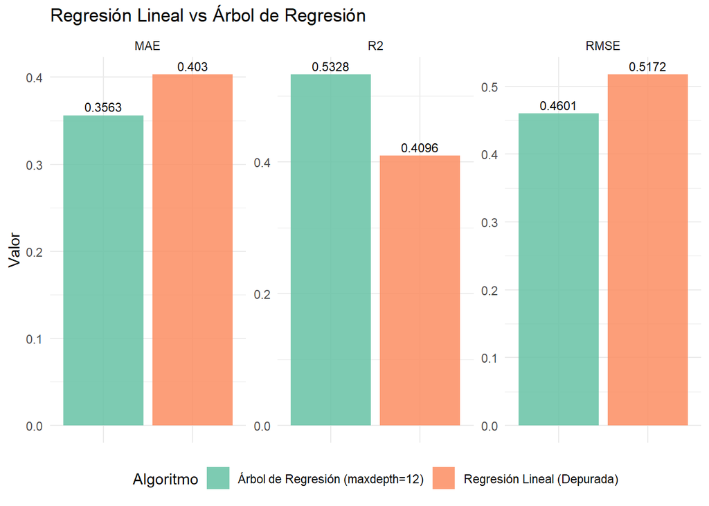

```r
# Gráfica comparativa
comp_long <- tidyr::pivot_longer(comparacion,
                                  cols      = c(R2, RMSE, MAE),
                                  names_to  = "Métrica",
                                  values_to = "Valor")

ggplot(comp_long, aes(x = Algoritmo, y = Valor, fill = Algoritmo)) +
  geom_col(alpha = 0.85) +
  geom_text(aes(label = round(Valor, 4)), vjust = -0.4, size = 3) +
  facet_wrap(~ Métrica, scales = "free_y") +
  scale_fill_brewer(palette = "Set2") +
  labs(title = "Regresión Lineal vs Árbol de Regresión",
       x = NULL, y = "Valor") +
  theme_minimal() +
  theme(axis.text.x = element_blank(),
        legend.position = "bottom")
```

**Comparación y conclusión:** La regresión lineal depurada del Lab 3 obtuvo R²=0.4096 y RMSE=0.5172. El mejor árbol de regresión obtuvo R²=0.5328 y RMSE=0.4601.

El árbol de regresión supera a la regresión lineal en R² y RMSE, lo cual refleja su capacidad para capturar relaciones no lineales y particiones del espacio de predictores que la regresión lineal no puede modelar. Sin embargo, el árbol es menos interpretable y más sensible al sobreajuste si no se controla la profundidad. Para el contexto de SmartStay, el árbol ofrece mejor precisión predictiva, mientras que la regresión lineal ofrece coeficientes directamente interpretables.

# 6. Creación de la variable categórica de precio (Actividad 6)

## 6.1 Análisis de la distribución para definir los límites

```r
# Estadísticas descriptivas del precio en el dataset limpio
resumen_precio <- data.frame(
  Estadístico = c("Mínimo", "Percentil 25", "Mediana",
                  "Media", "Percentil 75", "Percentil 90", "Máximo"),
  Valor = round(c(
    min(listings_clean$price),
    quantile(listings_clean$price, 0.25),
    median(listings_clean$price),
    mean(listings_clean$price),
    quantile(listings_clean$price, 0.75),
    quantile(listings_clean$price, 0.90),
    max(listings_clean$price)
  ), 2)
)
print(resumen_precio)
```

```
##    Estadístico  Valor
## 1       Mínimo   8.00
## 2 Percentil 25 116.00
## 3      Mediana 183.00
## 4        Media 233.75
## 5 Percentil 75 294.00
## 6 Percentil 90 467.00
## 7       Máximo 944.00
```

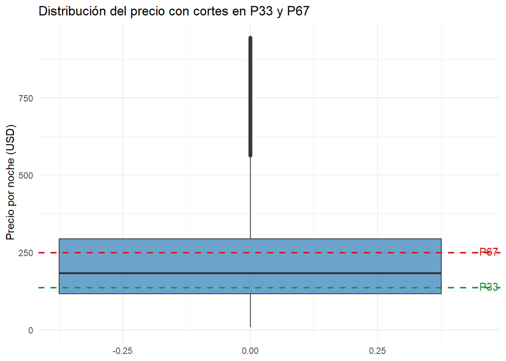

```r
# Boxplot del precio para visualizar la distribución
ggplot(listings_clean, aes(y = price)) +
  geom_boxplot(fill = "#2C7BB6", alpha = 0.7, outlier.alpha = 0.1) +
  geom_hline(yintercept = quantile(listings_clean$price, 0.33),
             color = "#1A9641", linetype = "dashed", linewidth = 0.8) +
  geom_hline(yintercept = quantile(listings_clean$price, 0.67),
             color = "#D7191C", linetype = "dashed", linewidth = 0.8) +
  annotate("text", x = 0.45,
           y = quantile(listings_clean$price, 0.33) + 5,
           label = paste0("P33 = $", round(quantile(listings_clean$price, 0.33))),
           color = "#1A9641", hjust = 0) +
  annotate("text", x = 0.45,
           y = quantile(listings_clean$price, 0.67) + 5,
           label = paste0("P67 = $", round(quantile(listings_clean$price, 0.67))),
           color = "#D7191C", hjust = 0) +
  labs(title = "Distribución del precio con cortes en P33 y P67",
       y = "Precio por noche (USD)") +
  theme_minimal()
```

## 6.2 Definición y justificación de los límites

```r
# Calcular los cortes basados en terciles (P33 y P67)
p33 <- quantile(listings_clean$price, 0.33)
p67 <- quantile(listings_clean$price, 0.67)

cat("Corte inferior (P33):", round(p33, 2), "USD\n")
```

```
## Corte inferior (P33): 136 USD
```

```r
cat("Corte superior (P67):", round(p67, 2), "USD\n\n")
```

```
## Corte superior (P67): 249 USD
```

```r
# Crear la variable categórica en listings_clean
listings_clean <- listings_clean %>%
  mutate(
    categoria_precio = case_when(
      price <= p33              ~ "Economica",
      price > p33 & price <= p67 ~ "Intermedia",
      price > p67               ~ "Cara"
    ),
    categoria_precio = factor(categoria_precio,
                               levels = c("Economica", "Intermedia", "Cara"))
  )

cat("Distribución de la variable categórica:\n")
```

```
## Distribución de la variable categórica:
```

```r
print(table(listings_clean$categoria_precio))
```

```
##
##  Economica Intermedia       Cara
##      23791      24318      23581
```

```r
cat("\nPorcentaje por categoría:\n")
```

```
##
## Porcentaje por categoría:
```

```r
print(round(prop.table(table(listings_clean$categoria_precio)) * 100, 1))
```

```
##
##  Economica Intermedia       Cara
##       33.2       33.9       32.9
```

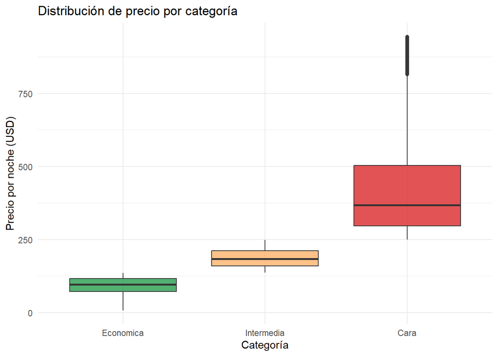

```r
# Boxplot de precio por categoría
ggplot(listings_clean, aes(x = categoria_precio, y = price,
                            fill = categoria_precio)) +
  geom_boxplot(alpha = 0.75, outlier.alpha = 0.1) +
  scale_fill_manual(values = c("#1A9641", "#FDAE61", "#D7191C")) +
  labs(title = "Distribución de precio por categoría",
       x = "Categoría", y = "Precio por noche (USD)") +
  theme_minimal() +
  theme(legend.position = "none")
```

**Justificación de los límites:** Se usaron los terciles P33 y P67 de la distribución del precio como puntos de corte. Esta elección tiene tres ventajas fundamentales:

1. **Fundamento estadístico en los datos:** Los terciles se calculan directamente a partir de la distribución observada de precios (rango $8 – $944), evitando cualquier criterio arbitrario externo.
2. **Clases balanceadas:** Dividir por terciles garantiza aproximadamente un 33% de observaciones por clase, lo cual es importante para que el árbol de clasificación no quede sesgado hacia una categoría mayoritaria.
3. **Interpretabilidad para el negocio:** Los límites resultantes (P33≈$136 y P67≈$249) tienen sentido económico: propiedades *Económicas* son las más accesibles, *Intermedias* representan el mercado estándar, y *Caras* corresponden al segmento premium de Airbnb, útil para SmartStay al segmentar su cartera de propiedades.

# 7. Árbol de Clasificación (Actividad 7)

## 7.1 Preparación del dataset de clasificación

```r
# Dataset para clasificación: sin price ni log_price como predictores
datos_clasif <- listings_clean %>%
  select(categoria_precio,
         accommodates, bedrooms, bathrooms, beds,
         minimum_nights, availability_365, number_of_reviews,
         review_scores_rating, review_scores_cleanliness,
         review_scores_value, reviews_per_month,
         calculated_host_listings_count) %>%
  na.omit()

cat("Observaciones para clasificación:", nrow(datos_clasif), "\n")
```

```
## Observaciones para clasificación: 60343
```

```r
cat("Distribución de clases:\n")
```

```
## Distribución de clases:
```

```r
print(table(datos_clasif$categoria_precio))
```

```
##
##  Economica Intermedia       Cara
##      20937      20665      18741
```

```r
# Split 80/20 con la misma semilla
set.seed(42)
n_cl        <- nrow(datos_clasif)
idx_cl      <- sample(1:n_cl, size = floor(0.8 * n_cl))
train_cl    <- datos_clasif[idx_cl, ]
test_cl     <- datos_clasif[-idx_cl, ]

cat("\nEntrenamiento:", nrow(train_cl), "| Prueba:", nrow(test_cl), "\n")
```

```
##
## Entrenamiento: 48274 | Prueba: 12069
```

```r
cat("Distribución en entrenamiento:\n")
```

```
## Distribución en entrenamiento:
```

```r
print(round(prop.table(table(train_cl$categoria_precio)) * 100, 1))
```

```
##
##  Economica Intermedia       Cara
##       34.8       34.2       31.0
```

## 7.2 Entrenamiento del árbol de clasificación

```r
# Árbol de clasificación con todos los predictores
arbol_clasif <- rpart(
  categoria_precio ~ accommodates + bedrooms + bathrooms + beds +
                     minimum_nights + availability_365 + number_of_reviews +
                     review_scores_rating + review_scores_cleanliness +
                     review_scores_value + reviews_per_month +
                     calculated_host_listings_count,
  data    = train_cl,
  method  = "class",
  control = rpart.control(cp = 0.001, maxdepth = 10)
)

# Resumen del árbol
printcp(arbol_clasif)
```

```
##
## Classification tree:
## rpart(formula = categoria_precio ~ accommodates + bedrooms +
##     bathrooms + beds + minimum_nights + availability_365 + number_of_reviews +
##     review_scores_rating + review_scores_cleanliness + review_scores_value +
##     reviews_per_month + calculated_host_listings_count, data = train_cl,
##     method = "class", control = rpart.control(cp = 0.001, maxdepth = 10))
##
## Variables actually used in tree construction:
## [1] accommodates                   bathrooms
## [3] beds                           calculated_host_listings_count
## [5] minimum_nights                 review_scores_cleanliness
## [7] review_scores_rating           reviews_per_month
##
## Root node error: 31460/48274 = 0.6517
##
## n= 48274
##
##           CP nsplit rel error  xerror      xstd
## 1  0.2695486      0   1.00000 1.00000 0.0033274
## 2  0.0616656      1   0.73045 0.73045 0.0034879
## 3  0.0199619      2   0.66879 0.66879 0.0034631
## 4  0.0038779      3   0.64882 0.64882 0.0034501
## 5  0.0034965      6   0.63528 0.63560 0.0034402
## 6  0.0030515      7   0.63179 0.63392 0.0034388
## 7  0.0022092      9   0.62568 0.62867 0.0034345
## 8  0.0019814     11   0.62127 0.62432 0.0034308
## 9  0.0018118     17   0.60706 0.62028 0.0034273
## 10 0.0016847     19   0.60343 0.61523 0.0034227
## 11 0.0012397     20   0.60175 0.60852 0.0034164
## 12 0.0011125     21   0.60051 0.60817 0.0034161
## 13 0.0010807     22   0.59940 0.60687 0.0034148
## 14 0.0010000     24   0.59723 0.60505 0.0034130
```

## 7.3 Visualización gráfica del árbol

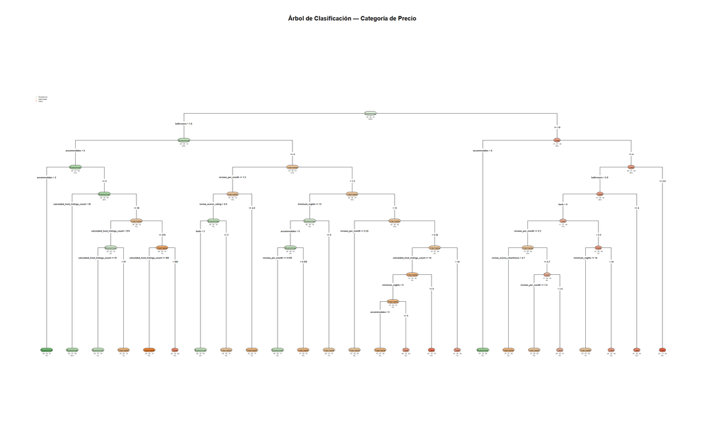

```r
# Gráfica completa del árbol
rpart.plot(
  arbol_clasif,
  type    = 4,
  extra   = 104,
  under   = TRUE,
  tweak   = 0.75,
  main    = "Árbol de Clasificación — Categoría de Precio",
  box.palette = list("Greens", "Oranges", "Reds")
)
```

## 7.4 Importancia de variables

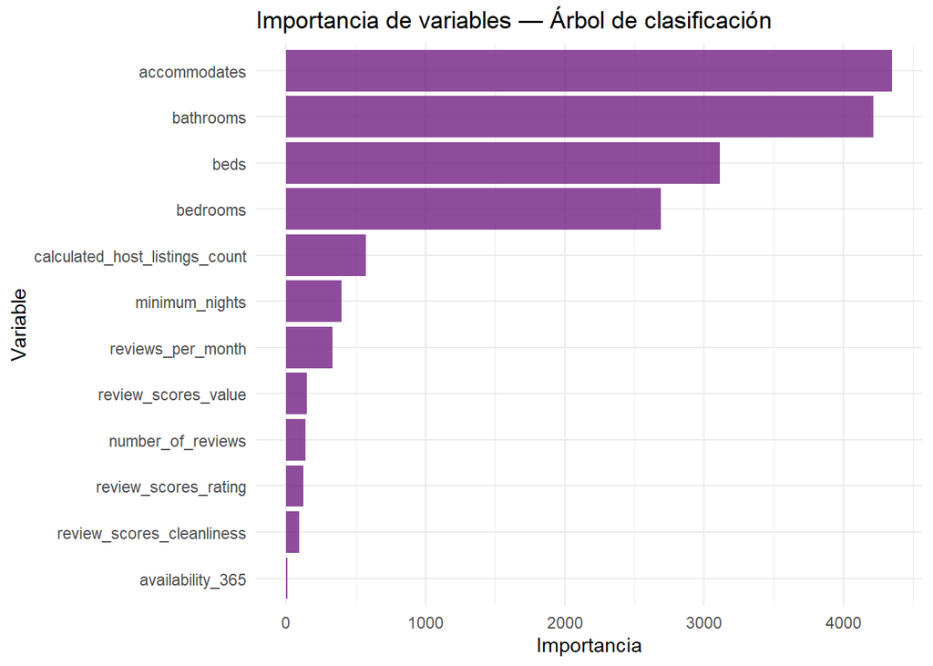

```r
imp_cl <- arbol_clasif$variable.importance
imp_cl_df <- data.frame(
  variable    = names(imp_cl),
  importancia = as.numeric(imp_cl)
) %>% arrange(desc(importancia))

ggplot(imp_cl_df, aes(x = reorder(variable, importancia), y = importancia)) +
  geom_col(fill = "#7B2D8B", alpha = 0.85) +
  coord_flip() +
  labs(title = "Importancia de variables — Árbol de clasificación",
       x = "Variable", y = "Importancia") +
  theme_minimal()
```

## 7.5 Evaluación sobre el conjunto de prueba

```r
# Predicciones sobre el conjunto de prueba
pred_cl <- predict(arbol_clasif, newdata = test_cl, type = "class")

# Accuracy
accuracy_cl <- mean(pred_cl == test_cl$categoria_precio)
cat("Accuracy en prueba:", round(accuracy_cl * 100, 2), "%\n\n")
```

```
## Accuracy en prueba: 61.3 %
```

```r
# Matriz de confusión
cm <- confusionMatrix(pred_cl, test_cl$categoria_precio)
print(cm$table)
```

```
##             Reference
## Prediction   Economica Intermedia Cara
##   Economica       3027       1277  333
##   Intermedia       896       1871  941
##   Cara             200       1024 2500
```

```r
cat("\nPrecision por clase:\n")
```

```
##
## Precision por clase:
```

```r
print(round(cm$byClass[, c("Precision", "Recall", "F1")], 3))
```

```
##                   Precision Recall    F1
## Class: Economica      0.653  0.734 0.691
## Class: Intermedia     0.505  0.448 0.475
## Class: Cara           0.671  0.662 0.667
```

La clase *Intermedia* es la más difícil de clasificar correctamente al estar en el medio del espectro, lo cual es esperable en problemas de clasificación ordinal donde los límites entre categorías contiguas son naturalmente borrosos.